# Analyzing Individual BGG Users

Phil Henrickson

2022-01-01

# **defdrago’s** BoardGameGeek Collection

This notebook contains a set of analyses for the selected user’s boardgamegeek collection. The bulk of the analysis is focused on building a user-specific predictive model to predict the games that defdrago is likely to own. This enables to ask questions like, based on the games the user currently owns, what games are a good fit for their collection? What upcoming games are they likely to purchase?

This analysis is based on data from BoardGameGeek that was last updated on **2021-12-20.**

# 1 Collection Overview

We can look at a basic description of the number of games that the user owns, has rated, has previously owned, etc.

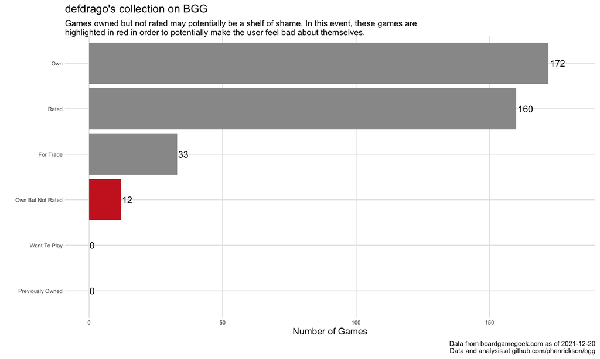

What years has the user owned/rated games from? While we can’t see when a user added or removed a game from their collection, we can look at their collection by the years in which their games were published.

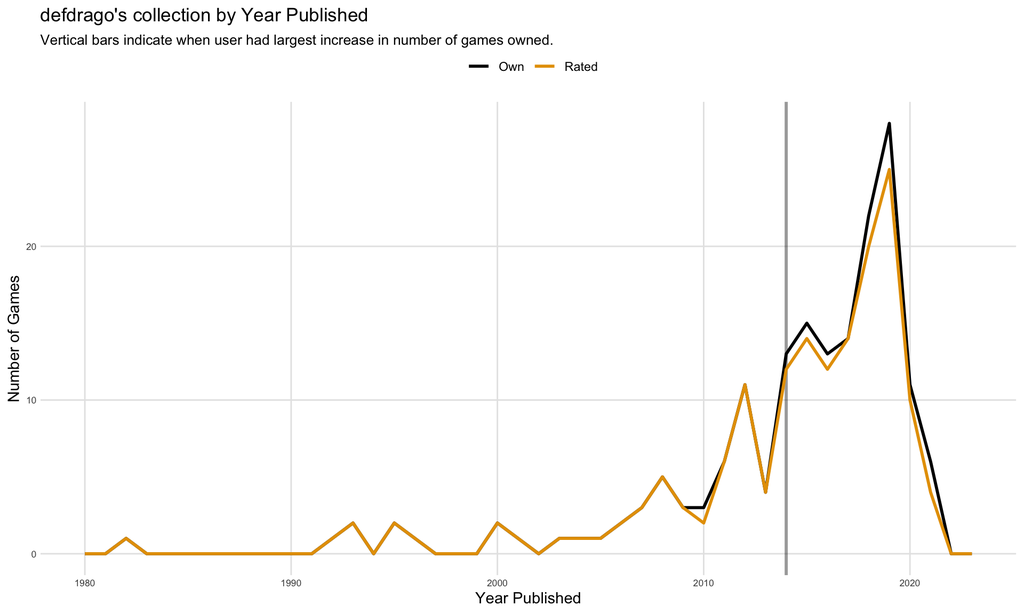

## 1.1 What types of games does defdrago own?

We can look at the most frequent types of categories, mechanics, designers, and artists that appear in a user’s collection.

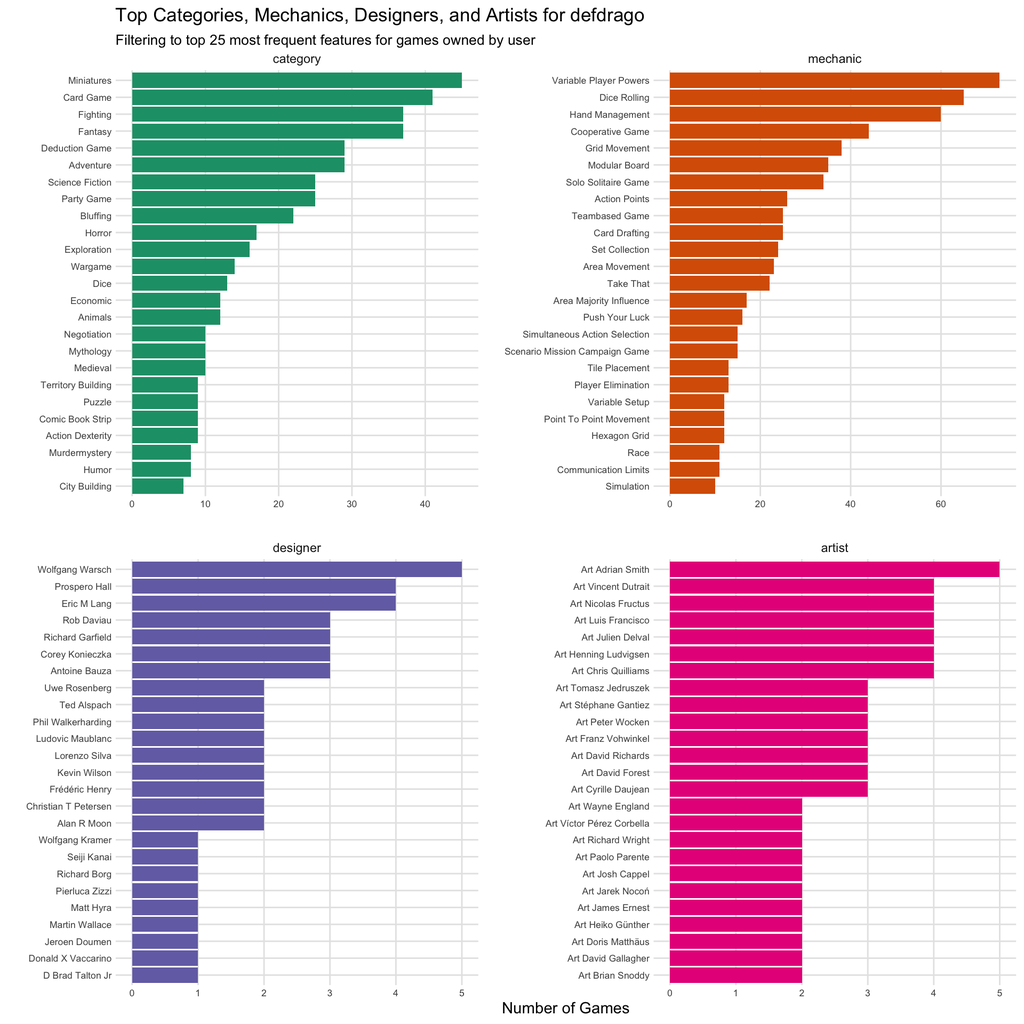

# 2 Modeling **defdrago’s** Collection

| username | dataset | period | games_owned | games_rated | games_played |
| --- | --- | --- | --- | --- | --- |
| defdrago | training | published before 2020 | 149 | 140 | 149 |
| defdrago | test | published 2020 or later | 17 | 14 | 17 |

There are two main (binary) outcomes we will be modeling for the user.

The first, **own** refers to whether the user currently lists a game as owned in their collection. The second, **played** refers to whether the user currently owns, has rated, or previously owned a game. This means the latter will generally have a larger list of games, but may still be a useful category to examine for people who play lots of games without necessarily owning them.

We will train predictive models to learn the probability that the user will own or play individual games based on their features.

## 2.1 Coefficients for defdrago

We can examine coefficients from the trained modes, which are penalized logistic regressions fit to our two main outcomes. Positive values indicate that a feature increases a user’s probabilility of owning/rating a game, while negative values indicate a feature decreases the probability.

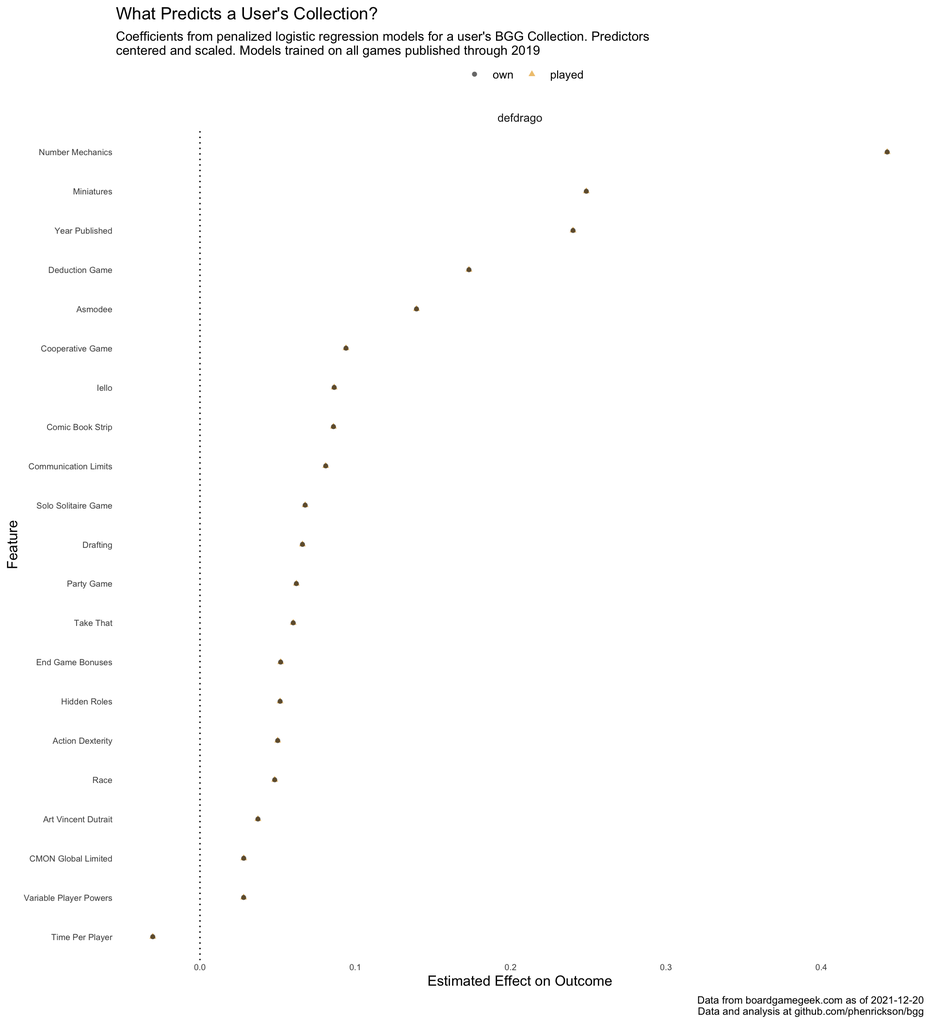

## 2.2 Visualizing Predictors for defdrago’s Collection

Why did the model identify these features? We can make density plots of the important features for predicting whether the user owned a game. Blue indicates the density for games owned by the user, while grey indicates the density for games not owned by the user.

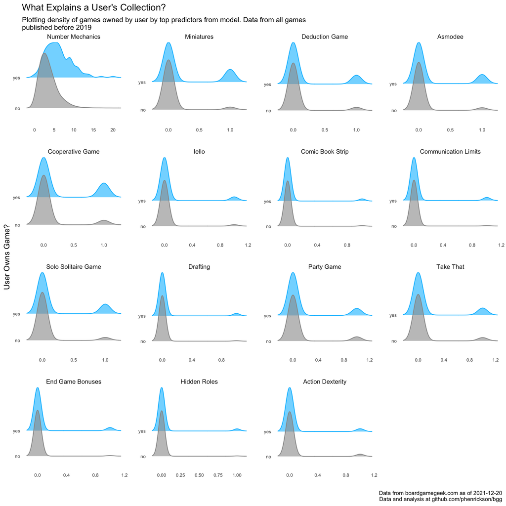

Binary predictors can be difficult to see with this visualization, so we can also directly examine the percentage of games in a user’s collection with a predictor vs the percentage of all games with that predictor.

| username | Feature | % of Games with Feature In_Collection | % of Games with Feature All_Games | Ratio |
| --- | --- | --- | --- | --- |
| defdrago | Communication Limits | 6.7% | 0.9% | 7.5 |
| defdrago | Hidden Roles | 4.7% | 0.7% | 7.1 |
| defdrago | CMON Global Limited | 4.7% | 0.8% | 6.2 |
| defdrago | End Game Bonuses | 6.7% | 1.2% | 5.6 |
| defdrago | Drafting | 5.4% | 1.0% | 5.5 |
| defdrago | Miniatures | 24.2% | 5.0% | 4.8 |
| defdrago | Comic Book Strip | 4.7% | 1.3% | 3.6 |
| defdrago | Asmodee | 18.1% | 5.2% | 3.5 |
| defdrago | Solo Solitaire Game | 18.8% | 5.7% | 3.3 |
| defdrago | Cooperative Game | 26.2% | 8.2% | 3.2 |
| defdrago | Race | 5.4% | 1.8% | 2.9 |
| defdrago | Deduction Game | 17.4% | 6.2% | 2.8 |
| defdrago | Line Drawing | 2.0% | 0.7% | 2.8 |
| defdrago | Horror | 10.7% | 3.8% | 2.8 |
| defdrago | Iello | 8.1% | 3.1% | 2.6 |
| defdrago | Fantasy Flight Games | 6.7% | 2.6% | 2.6 |
| defdrago | Variable Player Powers | 41.6% | 16.6% | 2.5 |
| defdrago | Grid Movement | 20.1% | 8.5% | 2.4 |
| defdrago | Take That | 14.1% | 6.5% | 2.2 |
| defdrago | Number | 2.0% | 0.9% | 2.2 |
| defdrago | Pegasus Spiele | 9.4% | 4.7% | 2.0 |
| defdrago | Paperandpencil | 4.7% | 2.7% | 1.8 |
| defdrago | Party Game | 14.1% | 8.4% | 1.7 |
| defdrago | Action Dexterity | 6.0% | 4.8% | 1.3 |
| defdrago | Area Majority Influence | 9.4% | 11.1% | 0.8 |

# 3 Assess Model’s Performance on Training Set

Before predicting games in upcoming years, we can examine how well the model did and what games it liked in the training set. In this case, we used resampling techniques (cross validation) to ensure that the model had not seen a game before making its predictions.

## 3.1 Separation Plot

An easy way to examine the performance of classification model is to view a separation plot. We plot the predicted probabilities from the model for every game (from resampling) from lowest to highest. We then overlay a blue line for any game that the user does own. A good classifier is one that is able to *separate* the blue (games owned by the user) from the white (games not owned by the user), with most of the blue occurring at the highest probabilities (right side of the chart).

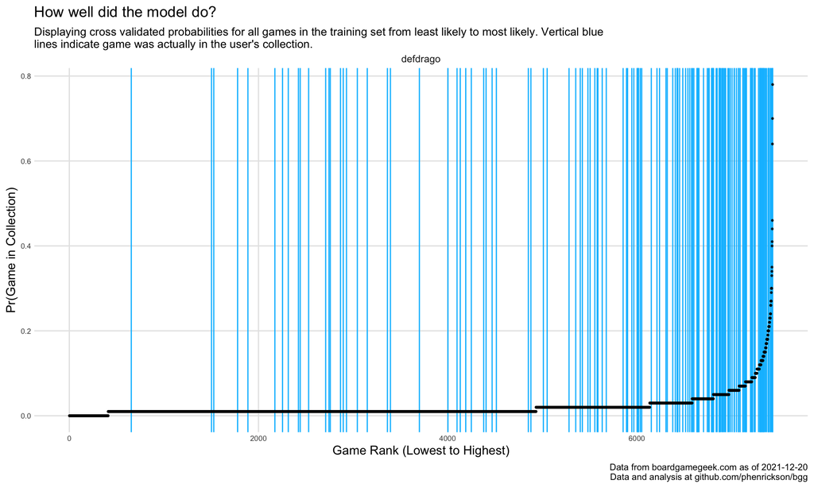

## 3.2 Top Games for **defdrago** from Training Set

We can display this information in table form, displaying the 100 games with the highest probability of ownership, adding a blue line when the user does own the game.

| username | yearpublished | game_id | name | pred_played | pred_own | actual_played | actual_own |
| --- | --- | --- | --- | --- | --- | --- | --- |
| defdrago | 2017 | 174430 | Gloomhaven | 0.78 | 0.78 | 1 | 1 |
| defdrago | 2018 | 205896 | Rising Sun | 0.70 | 0.70 | 1 | 1 |
| defdrago | 2014 | 156129 | Deception: Murder in Hong Kong | 0.64 | 0.64 | 0 | 0 |
| defdrago | 2016 | 198454 | When I Dream | 0.46 | 0.46 | 0 | 0 |
| defdrago | 2019 | 266507 | Clank!: Legacy – Acquisitions Incorporated | 0.44 | 0.44 | 0 | 0 |
| defdrago | 2018 | 167355 | Nemesis | 0.41 | 0.41 | 1 | 1 |
| defdrago | 2014 | 164265 | Witness | 0.40 | 0.40 | 0 | 0 |
| defdrago | 2000 | 478 | Citadels | 0.35 | 0.35 | 0 | 0 |
| defdrago | 2016 | 155821 | Inis | 0.34 | 0.34 | 0 | 0 |
| defdrago | 2019 | 269385 | The Lord of the Rings: Journeys in Middle-Earth | 0.33 | 0.33 | 0 | 0 |
| defdrago | 2019 | 283863 | The Magnificent | 0.30 | 0.30 | 0 | 0 |
| defdrago | 2019 | 274637 | Unmatched: Battle of Legends, Volume One | 0.30 | 0.30 | 0 | 0 |
| defdrago | 2019 | 276025 | Maracaibo | 0.30 | 0.30 | 0 | 0 |
| defdrago | 2012 | 104162 | Descent: Journeys in the Dark (Second Edition) | 0.30 | 0.30 | 0 | 0 |
| defdrago | 2015 | 175878 | 504 | 0.29 | 0.29 | 0 | 0 |
| defdrago | 2018 | 244711 | Newton | 0.27 | 0.27 | 0 | 0 |
| defdrago | 2019 | 169427 | Middara: Unintentional Malum – Act 1 | 0.27 | 0.27 | 0 | 0 |
| defdrago | 2017 | 188920 | This War of Mine: The Board Game | 0.27 | 0.27 | 0 | 0 |
| defdrago | 2016 | 205059 | Mansions of Madness: Second Edition | 0.27 | 0.27 | 1 | 1 |
| defdrago | 2019 | 249746 | Nanty Narking | 0.26 | 0.26 | 1 | 1 |
| defdrago | 2012 | 123096 | Space Cadets | 0.26 | 0.26 | 0 | 0 |
| defdrago | 2016 | 167791 | Terraforming Mars | 0.26 | 0.26 | 0 | 0 |
| defdrago | 2018 | 171964 | The Order of Vampire Hunters | 0.24 | 0.24 | 0 | 0 |
| defdrago | 2002 | 3955 | BANG! | 0.24 | 0.24 | 0 | 0 |
| defdrago | 2019 | 280136 | Paranormal Detectives | 0.24 | 0.24 | 0 | 0 |
| defdrago | 2014 | 157354 | Five Tribes | 0.23 | 0.23 | 0 | 0 |
| defdrago | 2012 | 104710 | Wiz-War (Eighth Edition) | 0.23 | 0.23 | 0 | 0 |
| defdrago | 2013 | 143741 | BANG! The Dice Game | 0.23 | 0.23 | 0 | 0 |
| defdrago | 2016 | 198773 | Codenames: Pictures | 0.23 | 0.23 | 0 | 0 |
| defdrago | 2005 | 15062 | Shadows over Camelot | 0.23 | 0.23 | 0 | 0 |

[output cut: 70 more lines]

We can also more formally assess how well the model did in resampling by looking at the area under the receiver operating characteristic. A perfect model would receive a score of 1, while a model that cannot predict the outcome will default to a score of 0.5. The extent to which something is a *good* score depends on the setting, but generally anything in the .8 to .9 range is very good while the .7 to .8 range is perfectly acceptable.

| username | outcome_type | .metric | .estimator | .estimate |
| --- | --- | --- | --- | --- |
| defdrago | own | roc_auc | binary | 0.799 |
| defdrago | played | roc_auc | binary | 0.799 |

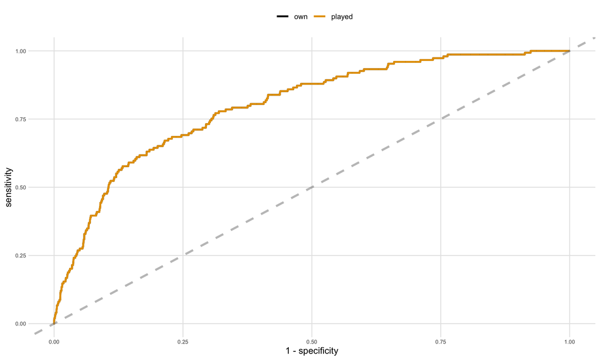

Another way to think about the model performance is to view its lift, or its ability to detect the positive outcomes over that of a null model. High lift indicates the model can much more quickly find all of the positive outcomes (in this case, games owned or played by the user), while a model with no lift is no better than random guessing.

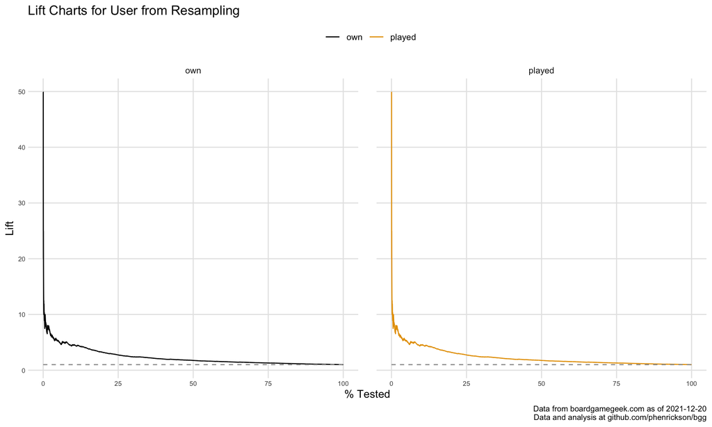

## 3.3 Most and Least Likely Games

What games does the model think defdrago is **most likely to own** that are **not** in their collection?

| username | yearpublished | game_id | name | pred_own | actual_own |
| --- | --- | --- | --- | --- | --- |
| defdrago | 2014 | 156129 | Deception: Murder in Hong Kong | 0.64 | 0 |
| defdrago | 2016 | 198454 | When I Dream | 0.46 | 0 |
| defdrago | 2019 | 266507 | Clank!: Legacy – Acquisitions Incorporated | 0.44 | 0 |
| defdrago | 2014 | 164265 | Witness | 0.40 | 0 |
| defdrago | 2000 | 478 | Citadels | 0.35 | 0 |

What games does the model think defdrago is **least likely to own** that **are** in their collection?

| username | yearpublished | game_id | name | pred_own | actual_own |
| --- | --- | --- | --- | --- | --- |
| defdrago | 2019 | 253719 | Getaway Driver | 0.01 | 1 |
| defdrago | 2010 | 89409 | BattleCON: War of Indines | 0.01 | 1 |
| defdrago | 2014 | 126996 | King's Forge | 0.01 | 1 |
| defdrago | 2006 | 25669 | Qwirkle | 0.01 | 1 |
| defdrago | 2016 | 194607 | Mystic Vale | 0.01 | 1 |

## 3.4 Top Games by Year

Top 25 games most likely to be owned by the user in each year, highlighting in blue the games that the user has owned/played.

| rank | 2011 | 2012 | 2013 | 2014 | 2015 | 2016 | 2017 | 2018 | 2019 |
| --- | --- | --- | --- | --- | --- | --- | --- | --- | --- |
| 1 | Discworld: Ankh-Morpork | Descent: Journeys in the Dark (Second Edition) | BANG! The Dice Game | Deception: Murder in Hong Kong | 504 | When I Dream | Gloomhaven | Rising Sun | Clank!: Legacy – Acquisitions Incorporated |
| 2 | Gears of War: The Board Game | Space Cadets | City of Remnants | Witness | Blood Rage | Inis | This War of Mine: The Board Game | Nemesis | The Lord of the Rings: Journeys in Middle-Earth |
| 3 | Mage Knight Board Game | Wiz-War (Eighth Edition) | Patchistory | Five Tribes | Mysterium | Mansions of Madness: Second Edition | Codenames: Duet | Newton | The Magnificent |
| 4 | Dungeons & Dragons: The Legend of Drizzt Board Game | Zombicide | Zombicide Season 2: Prison Outbreak | Ultimate Werewolf | Codenames | Terraforming Mars | Breaking Bad: The Board Game | The Order of Vampire Hunters | Unmatched: Battle of Legends, Volume One |
| 5 | Takenoko | Robinson Crusoe: Adventures on the Cursed Island | Legacy: The Testament of Duke de Crecy | Spurs: A Tale in the Old West | Super Dungeon Explore: Forgotten King | Codenames: Pictures | Summit: The Board Game | Big Trouble in Little China: The Game | Maracaibo |
| 6 | Tragedy Looper | Keyflower | Concept | Star Wars: Imperial Assault | Zombicide Season 3: Rue Morgue | Scythe | Magic Maze | Renegade | Middara: Unintentional Malum – Act 1 |
| 7 | Flash Point: Fire Rescue | Coup | Level 7 [Omega Protocol] | Patchwork | Zombicide: Black Plague | The Oregon Trail Card Game | Muse | Street Masters | Nanty Narking |
| 8 | Mansions of Madness | Spartacus: A Game of Blood and Treachery | Impulse | Arcadia Quest | Specter Ops | Dead of Winter: The Long Night | Mythic Battles: Pantheon | Hail Hydra | Paranormal Detectives |
| 9 | Dungeon Fighter | Bolt Action | Room 25 | Imperial Settlers | Dungeons & Dragons: Temple of Elemental Evil Board Game | Beyond Baker Street | Massive Darkness | Shadows: Amsterdam | Core Space |
| 10 | Dungeons & Dragons: Wrath of Ashardalon Board Game | The Resistance: Avalon | Forbidden Desert | Alchemists | The Pursuit of Happiness | New Angeles | Dungeons & Dragons: Tomb of Annihilation Board Game | The World of SMOG: Rise of Moloch | Arena: The Contest |
| 11 | Ninja: Legend of the Scorpion Clan | Mice and Mystics | Dark Darker Darkest | Galaxy Defenders | X-Men: Mutant Revolution | Teenage Mutant Ninja Turtles: Shadows of the Past | Star Saga | Lords of Hellas | Unmatched: Robin Hood vs. Bigfoot |
| 12 | Fortune and Glory: The Cliffhanger Game | Rumble in the Dungeon | Pathfinder Adventure Card Game: Rise of the Runelords – Base Set | Legendary Encounters: An Alien Deck Building Game | Burgle Bros. | Mechs vs. Minions | Fate of the Elder Gods | Darklight: Memento Mori | Zombicide: Invader |
| 13 | Dreadfleet | Il Vecchio | BioShock Infinite: The Siege of Columbia | Golem Arcana | Forbidden Stars | Perdition's Mouth: Abyssal Rift | Dark Souls: The Board Game | The Edge: Dawnfall | HATE |
| 14 | The Adventurers: The Pyramid of Horus | Smash Up | Tajemnicze Domostwo | Pandemic: The Cure | Journey: Wrath of Demons | Black Orchestra | Betrayal at Baldur's Gate | Kick-Ass: The Board Game | Sierra West |
| 15 | Super Dungeon Explore | One Night Werewolf | Lewis & Clark: The Expedition | Dead of Winter: A Crossroads Game | Alien vs Predator: The Hunt Begins | Agricola (Revised Edition) | Folklore: The Affliction | Betrayal Legacy | Judge Dredd: Helter Skelter |
| 16 | Munchkin Axe Cop | Seasons | Rivet Wars: Eastern Front | Shadows of Brimstone: City of the Ancients | Krosmaster: Quest | Captain Sonar | Aristeia! | Muse: Awakenings | Last Bastion |
| 17 | Sentinels of the Multiverse | Sewer Pirats | Tash-Kalar: Arena of Legends | La Granja | Tiny Epic Galaxies | The Others | Pulsar 2849 | The Grizzled: Armistice Edition | Quodd Heroes |
| 18 | Star Trek: Fleet Captains | Archipelago | Corto | Outfoxed! | Exploding Kittens | Islebound | 878 Vikings: Invasions of England | The Pirate Republic | Era: Medieval Age |
| 19 | Elder Sign | Escape: The Curse of the Temple | Bomb Squad | Good Cop Bad Cop | Raptor | Hit Z Road | Mountains of Madness | Batman: The Animated Series – Gotham City Under Siege | Hellboy: The Board Game |
| 20 | Chaostle | War of the Ring: Second Edition | BattleLore: Second Edition | One Night Ultimate Werewolf | Fireteam Zero | Cry Havoc | My Little Scythe | Battlestar Galactica: Starship Battles – Starter Set | Zombicide: Dark Side |
| 21 | Panic Station | Kairo | Sedition Wars: Battle for Alabaster | Praetor | Salem 1692 | Robo Rally | Exploding Kittens: Party Pack | Vengeance | Horrified |
| 22 | Rumble in the House | Last Night on Earth: Timber Peak | Justice League: Axis of Villains Strategy Game | Shadows of Brimstone: Swamps of Death | March of the Ants | Timebomb | Sword & Sorcery | Specter Ops: Broken Covenant | Batman: Gotham City Chronicles |
| 23 | Nightfall | Kemet | Eldritch Horror | HINT | Exploding Kittens: NSFW Deck | Sherlock Holmes Consulting Detective: Jack the Ripper & West End Adventures | Harvest Dice | Champions of Hara | Barrage |
| 24 | A Few Acres of Snow | DreadBall: The Futuristic Sports Game | Police Precinct | Myth | Elysium | Virus | Alien vs Predator: The Hunt Begins (Second Edition) | First Contact | Obscurio |
| 25 | Space Empires: 4X | Targi | Dungeon Twister: The Card Game | Heroes of Normandie | Argonauts | Secret Hitler | Richard the Lionheart | Dungeon Alliance | Tiny Towns |

## 3.5 Interactive Predictions from Resampling

Interactive table for predictions from resampling.

|  | username | yearpublished | rank | game_id | name | pred_played | pred_own | actual_played | actual_own |
| --- | --- | --- | --- | --- | --- | --- | --- | --- | --- |
| 1 | defdrago | 1900 | 5640 | 2136 | Pachisi | 0.01 | 0.01 | 0 | 0 |
| 2 | defdrago | 1900 | 5880 | 2785 | Game of Goose | 0.01 | 0.01 | 0 | 0 |
| 3 | defdrago | 1900 | 6037 | 10799 | Old Maid | 0.01 | 0.01 | 0 | 0 |
| 4 | defdrago | 1900 | 7028 | 5546 | Marbles | 0 | 0 | 0 | 0 |
| 5 | defdrago | 1900 | 7029 | 11901 | Tic-Tac-Toe | 0 | 0 | 0 | 0 |
| 6 | defdrago | 1900 | 7035 | 188 | Go | 0 | 0 | 0 | 0 |
| 7 | defdrago | 1900 | 7045 | 171 | Chess | 0 | 0 | 0 | 0 |
| 8 | defdrago | 1900 | 7047 | 2065 | Shogi | 0 | 0 | 0 | 0 |
| 9 | defdrago | 1900 | 7048 | 2393 | Xiangqi | 0 | 0 | 0 | 0 |
| 10 | defdrago | 1900 | 7062 | 26952 | International Checkers | 0 | 0 | 0 | 0 |

[output cut: 7426 more lines]

# 4 Validating the Model on 2020

How well did a model trained on a user’s collection through 2019 perform in predicting games for the user from 2020?

| username | outcome_type | yearpublished | .metric | .estimator | .estimate |
| --- | --- | --- | --- | --- | --- |
| defdrago | own | 2020 | roc_auc | binary | 0.685 |
| defdrago | played | 2020 | roc_auc | binary | 0.685 |

Table of top 25 games from 2020, highlighting games that the user owns.

| username | yearpublished | game_id | name | pred_own | pred_played | actual_own | actual_played |
| --- | --- | --- | --- | --- | --- | --- | --- |
| defdrago | 2020 | 291457 | Gloomhaven: Jaws of the Lion | 0.80 | 0.80 | 0 | 0 |
| defdrago | 2020 | 256317 | Guild Master | 0.40 | 0.40 | 0 | 0 |
| defdrago | 2020 | 184267 | On Mars | 0.32 | 0.32 | 0 | 0 |
| defdrago | 2020 | 292333 | Cowboys II: Cowboys & Indians Edition | 0.32 | 0.32 | 0 | 0 |
| defdrago | 2020 | 282922 | Windward | 0.28 | 0.28 | 0 | 0 |
| defdrago | 2020 | 257145 | Teenage Mutant Ninja Turtles Adventures: City Fall | 0.25 | 0.25 | 0 | 0 |
| defdrago | 2020 | 302193 | Wonder Woman: Challenge of the Amazons | 0.22 | 0.22 | 0 | 0 |
| defdrago | 2020 | 316750 | The Princess Bride Adventure Book Game | 0.22 | 0.22 | 0 | 0 |
| defdrago | 2020 | 294484 | Unmatched: Cobble & Fog | 0.20 | 0.20 | 0 | 0 |
| defdrago | 2020 | 301767 | Mysterium Park | 0.20 | 0.20 | 0 | 0 |
| defdrago | 2020 | 295905 | Cosmic Frog | 0.19 | 0.19 | 0 | 0 |
| defdrago | 2020 | 236861 | Full Moon Jacket | 0.17 | 0.17 | 0 | 0 |
| defdrago | 2020 | 304434 | Victim: The Cursed Forest | 0.17 | 0.17 | 0 | 0 |
| defdrago | 2020 | 325635 | Unmatched: Little Red Riding Hood vs. Beowulf | 0.17 | 0.17 | 0 | 0 |
| defdrago | 2020 | 256940 | Krosmaster: Blast | 0.16 | 0.16 | 0 | 0 |
| defdrago | 2020 | 263192 | Teenage Mutant Ninja Turtles Adventures: Change is Constant | 0.16 | 0.16 | 1 | 1 |
| defdrago | 2020 | 302465 | Obsidia | 0.15 | 0.15 | 0 | 0 |
| defdrago | 2020 | 315196 | Dungeons & Dragons: Adventure Begins | 0.15 | 0.15 | 0 | 0 |
| defdrago | 2020 | 315954 | Hunt A Killer: Death at the Dive Bar | 0.15 | 0.15 | 0 | 0 |
| defdrago | 2020 | 323784 | Ghost Letters | 0.15 | 0.15 | 0 | 0 |
| defdrago | 2020 | 256999 | Project: ELITE | 0.13 | 0.13 | 0 | 0 |
| defdrago | 2020 | 262274 | D6: Dungeons, Dudes, Dames, Danger, Dice and Dragons! | 0.13 | 0.13 | 0 | 0 |
| defdrago | 2020 | 315060 | Unmatched: Buffy the Vampire Slayer | 0.13 | 0.13 | 0 | 0 |
| defdrago | 2020 | 326767 | Infinity N4: Core Rules | 0.13 | 0.13 | 0 | 0 |
| defdrago | 2020 | 263085 | Darksiders: The Forbidden Land | 0.12 | 0.12 | 0 | 0 |

# 5 Predicting Upcoming Games (2020 and On) for **defdrago**

Examine the top games for the test set.

| username | yearpublished | game_id | name | rank | own | played |
| --- | --- | --- | --- | --- | --- | --- |
| defdrago | 2020 | 291457 | Gloomhaven: Jaws of the Lion | 1 | 0.80 | 0.80 |
| defdrago | 2020 | 256317 | Guild Master | 2 | 0.40 | 0.40 |
| defdrago | 2020 | 292333 | Cowboys II: Cowboys & Indians Edition | 3 | 0.32 | 0.32 |
| defdrago | 2020 | 184267 | On Mars | 4 | 0.32 | 0.32 |
| defdrago | 2020 | 282922 | Windward | 5 | 0.28 | 0.28 |
| defdrago | 2020 | 257145 | Teenage Mutant Ninja Turtles Adventures: City Fall | 6 | 0.25 | 0.25 |
| defdrago | 2020 | 316750 | The Princess Bride Adventure Book Game | 7 | 0.22 | 0.22 |
| defdrago | 2020 | 302193 | Wonder Woman: Challenge of the Amazons | 8 | 0.22 | 0.22 |
| defdrago | 2020 | 301767 | Mysterium Park | 9 | 0.20 | 0.20 |
| defdrago | 2020 | 294484 | Unmatched: Cobble & Fog | 10 | 0.20 | 0.20 |
| defdrago | 2020 | 295905 | Cosmic Frog | 11 | 0.19 | 0.19 |
| defdrago | 2020 | 236861 | Full Moon Jacket | 12 | 0.17 | 0.17 |
| defdrago | 2020 | 325635 | Unmatched: Little Red Riding Hood vs. Beowulf | 13 | 0.17 | 0.17 |
| defdrago | 2020 | 304434 | Victim: The Cursed Forest | 14 | 0.17 | 0.17 |
| defdrago | 2020 | 263192 | Teenage Mutant Ninja Turtles Adventures: Change is Constant | 15 | 0.16 | 0.16 |
| defdrago | 2020 | 256940 | Krosmaster: Blast | 16 | 0.16 | 0.16 |
| defdrago | 2020 | 315954 | Hunt A Killer: Death at the Dive Bar | 17 | 0.15 | 0.15 |
| defdrago | 2020 | 323784 | Ghost Letters | 18 | 0.15 | 0.15 |
| defdrago | 2020 | 302465 | Obsidia | 19 | 0.15 | 0.15 |
| defdrago | 2020 | 315196 | Dungeons & Dragons: Adventure Begins | 20 | 0.15 | 0.15 |
| defdrago | 2020 | 326767 | Infinity N4: Core Rules | 21 | 0.13 | 0.13 |
| defdrago | 2020 | 315060 | Unmatched: Buffy the Vampire Slayer | 22 | 0.13 | 0.13 |
| defdrago | 2020 | 262274 | D6: Dungeons, Dudes, Dames, Danger, Dice and Dragons! | 23 | 0.13 | 0.13 |
| defdrago | 2020 | 256999 | Project: ELITE | 24 | 0.13 | 0.13 |
| defdrago | 2020 | 295604 | Rangers of Shadow Deep: Deluxe Edition | 25 | 0.12 | 0.12 |
| defdrago | 2021 | 285967 | Ankh: Gods of Egypt | 1 | 0.41 | 0.41 |
| defdrago | 2021 | 298102 | Roll Camera!: The Filmmaking Board Game | 2 | 0.39 | 0.39 |
| defdrago | 2021 | 291847 | Mantis Falls | 3 | 0.29 | 0.29 |
| defdrago | 2021 | 295785 | Euthia: Torment of Resurrection | 4 | 0.26 | 0.26 |
| defdrago | 2021 | 251661 | Oathsworn: Into the Deepwood | 5 | 0.25 | 0.25 |
| defdrago | 2021 | 310873 | Carnegie | 6 | 0.23 | 0.23 |
| defdrago | 2021 | 273330 | Bloodborne: The Board Game | 7 | 0.22 | 0.22 |
| defdrago | 2021 | 260524 | Beyond Humanity: Colonies | 8 | 0.20 | 0.20 |
| defdrago | 2021 | 336195 | League of Dungeoneers | 9 | 0.19 | 0.19 |
| defdrago | 2021 | 310100 | Nemesis: Lockdown | 10 | 0.19 | 0.19 |
| defdrago | 2021 | 262201 | Sword & Sorcery: Ancient Chronicles | 11 | 0.17 | 0.17 |
| defdrago | 2021 | 239189 | Chronicle X | 12 | 0.17 | 0.17 |
| defdrago | 2021 | 260789 | Assassin's Creed: Brotherhood of Venice | 13 | 0.17 | 0.17 |
| defdrago | 2021 | 316287 | Quest | 14 | 0.16 | 0.16 |
| defdrago | 2021 | 340237 | Wonder Book | 15 | 0.15 | 0.15 |
| defdrago | 2021 | 299566 | Batman: The Animated Series Adventures – Shadow of the Bat | 16 | 0.15 | 0.15 |
| defdrago | 2021 | 343562 | Horrified: American Monsters | 17 | 0.15 | 0.15 |
| defdrago | 2021 | 291859 | Riftforce | 18 | 0.14 | 0.14 |
| defdrago | 2021 | 335764 | Unmatched: Battle of Legends, Volume Two | 19 | 0.14 | 0.14 |
| defdrago | 2021 | 308989 | Bristol 1350 | 20 | 0.14 | 0.14 |
| defdrago | 2021 | 340466 | Unfathomable | 21 | 0.14 | 0.14 |
| defdrago | 2021 | 249277 | Brazil: Imperial | 22 | 0.13 | 0.13 |
| defdrago | 2021 | 332075 | Warhammer Quest: Cursed City | 23 | 0.12 | 0.12 |
| defdrago | 2021 | 275802 | Carnival Zombie: 2nd Edition | 24 | 0.11 | 0.11 |
| defdrago | 2021 | 286751 | Zombicide: 2nd Edition | 25 | 0.11 | 0.11 |
| defdrago | 2022 | 295770 | Frosthaven | 1 | 0.65 | 0.65 |
| defdrago | 2022 | 331106 | The Witcher: Old World | 2 | 0.54 | 0.54 |
| defdrago | 2022 | 322524 | Bardsung | 3 | 0.45 | 0.45 |
| defdrago | 2022 | 317321 | Darkest Dungeon: The Board Game | 4 | 0.30 | 0.30 |
| defdrago | 2022 | 317511 | Tindaya | 5 | 0.28 | 0.28 |
| defdrago | 2022 | 271601 | Feed the Kraken | 6 | 0.27 | 0.27 |
| defdrago | 2022 | 274471 | Malhya: Lands of Legends | 7 | 0.24 | 0.24 |
| defdrago | 2022 | 283137 | Human Punishment: The Beginning | 8 | 0.20 | 0.20 |
| defdrago | 2022 | 311823 | Nova Aetas Renaissance | 9 | 0.16 | 0.16 |
| defdrago | 2022 | 338067 | 6: Siege – The Board Game | 10 | 0.15 | 0.15 |
| defdrago | 2022 | 252315 | The Everrain | 11 | 0.12 | 0.12 |
| defdrago | 2022 | 316915 | U.S.S. Freedom | 12 | 0.12 | 0.12 |
| defdrago | 2022 | 320718 | Hidden Leaders | 13 | 0.11 | 0.11 |
| defdrago | 2022 | 315610 | Massive Darkness 2: Hellscape | 14 | 0.11 | 0.11 |
| defdrago | 2022 | 273814 | Deliverance | 15 | 0.10 | 0.10 |
| defdrago | 2022 | 240980 | Blood on the Clocktower | 16 | 0.09 | 0.09 |
| defdrago | 2022 | 282775 | The Warp | 17 | 0.09 | 0.09 |
| defdrago | 2022 | 303731 | Primal: The Awakening | 18 | 0.09 | 0.09 |
| defdrago | 2022 | 256680 | Return to Dark Tower | 19 | 0.09 | 0.09 |
| defdrago | 2022 | 304051 | Creature Comforts | 20 | 0.09 | 0.09 |
| defdrago | 2022 | 312959 | Rallyman: DIRT | 21 | 0.08 | 0.08 |
| defdrago | 2022 | 275284 | Arkeis | 22 | 0.08 | 0.08 |
| defdrago | 2022 | 277025 | Vampire: The Masquerade – CHAPTERS | 23 | 0.08 | 0.08 |
| defdrago | 2022 | 280726 | Legacies | 24 | 0.08 | 0.08 |
| defdrago | 2022 | 242705 | Aeon Trespass: Odyssey | 25 | 0.07 | 0.07 |

## 5.1 Interactive Table for Upcoming Games 2020 and On

|  | username | yearpublished | game_id | name | rank | own | played |
| --- | --- | --- | --- | --- | --- | --- | --- |
| 1 | defdrago | 2020 | 291457 | Gloomhaven: Jaws of the Lion | 1 | 0.8 | 0.8 |
| 2 | defdrago | 2022 | 295770 | Frosthaven | 2 | 0.65 | 0.65 |
| 3 | defdrago | 2022 | 331106 | The Witcher: Old World | 3 | 0.54 | 0.54 |
| 4 | defdrago | 2022 | 322524 | Bardsung | 4 | 0.45 | 0.45 |
| 5 | defdrago | 2021 | 285967 | Ankh: Gods of Egypt | 5 | 0.41 | 0.41 |
| 6 | defdrago | 2020 | 256317 | Guild Master | 6 | 0.4 | 0.4 |
| 7 | defdrago | 2021 | 298102 | Roll Camera!: The Filmmaking Board Game | 7 | 0.39 | 0.39 |
| 8 | defdrago | 2020 | 292333 | Cowboys II: Cowboys &amp; Indians Edition | 8 | 0.32 | 0.32 |
| 9 | defdrago | 2020 | 184267 | On Mars | 9 | 0.32 | 0.32 |
| 10 | defdrago | 2022 | 317321 | Darkest Dungeon: The Board Game | 10 | 0.3 | 0.3 |

[output cut: 1627 more lines]